# Students Data Analysis

Hasibullah Mahmood

April 2, 2020

## Import the relevant libraries

```r
library(plyr)
```

```r
library(ggplot2)
library(gridExtra)
```

## Load the data

```r
students <- read.csv("students.csv")
attach(students)
head(students)
```

```
##   stud.id                name gender age height weight   religion nc.score
## 1  833917 Gonzales, Christina Female  19    160   64.8     Muslim     1.91
## 2  898539      Lozano, T'Hani Female  19    172   73.0      Other     1.56
## 3  379678      Williams, Hanh Female  22    168   70.6 Protestant     1.24
## 4  807564         Nem, Denzel   Male  19    183   79.7      Other     1.37
## 5  383291     Powell, Heather Female  21    175   71.4   Catholic     1.46
## 6  256074      Perez, Jadrian   Male  19    189   85.8   Catholic     1.34
##   semester                  major                      minor score1 score2
## 1      1st      Political Science            Social Sciences     NA     NA
## 2      2nd        Social Sciences Mathematics and Statistics     NA     NA
## 3      3rd        Social Sciences Mathematics and Statistics     45     46
## 4      2nd Environmental Sciences Mathematics and Statistics     NA     NA
## 5      1st Environmental Sciences Mathematics and Statistics     NA     NA
## 6      2nd      Political Science Mathematics and Statistics     NA     NA
##   online.tutorial graduated salary
## 1               0         0     NA
## 2               0         0     NA
## 3               0         0     NA
## 4               0         0     NA
## 5               0         0     NA
## 6               0         0     NA
```

```r
# Transform variables to factors with descriptive levels
students <- transform(students,
                     online.tutorial = as.factor(mapvalues(online.tutorial,
                                                         c(0,1), c("no", "yes"))),
                     graduated = as.factor(mapvalues(graduated,
                                                        c(0,1), c("no", "yes")))
                     )
head(students)
```

```
##   stud.id                name gender age height weight   religion nc.score
## 1  833917 Gonzales, Christina Female  19    160   64.8     Muslim     1.91
## 2  898539      Lozano, T'Hani Female  19    172   73.0      Other     1.56
## 3  379678      Williams, Hanh Female  22    168   70.6 Protestant     1.24
## 4  807564         Nem, Denzel   Male  19    183   79.7      Other     1.37
## 5  383291     Powell, Heather Female  21    175   71.4   Catholic     1.46
## 6  256074      Perez, Jadrian   Male  19    189   85.8   Catholic     1.34
##   semester                  major                      minor score1 score2
## 1      1st      Political Science            Social Sciences     NA     NA
## 2      2nd        Social Sciences Mathematics and Statistics     NA     NA
## 3      3rd        Social Sciences Mathematics and Statistics     45     46
## 4      2nd Environmental Sciences Mathematics and Statistics     NA     NA
## 5      1st Environmental Sciences Mathematics and Statistics     NA     NA
## 6      2nd      Political Science Mathematics and Statistics     NA     NA
##   online.tutorial graduated salary
## 1              no        no     NA
## 2              no        no     NA
## 3              no        no     NA
## 4              no        no     NA
## 5              no        no     NA
## 6              no        no     NA
```

## Some basic analysis

```r
cat("Total number of Variables:", length(students),
    "\nTotal number of students:", length(stud.id))
```

```
## Total number of Variables: 16
## Total number of students: 8239
```

#### Checking summary of gender

```r
summary(gender)
```

```
## Female   Male
##   4110   4129
```

#### Analyzing Students Age

```r
summary(age)
```

```
##    Min. 1st Qu.  Median    Mean 3rd Qu.    Max.
##   18.00   20.00   21.00   22.54   23.00   64.00
```

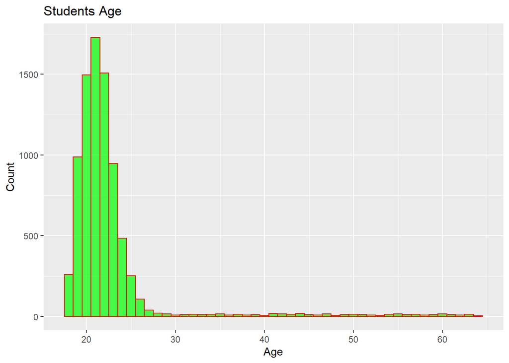

```r
ggplot(data=students, aes(x=students$age)) +
  geom_histogram(binwidth=1, col="red", fill="green", alpha=0.7)+
  labs(title = "Students Age", x="Age", y="Count")
```

The above figure shows most of students are between 18-25 years old.

#### Analyzing Students Height

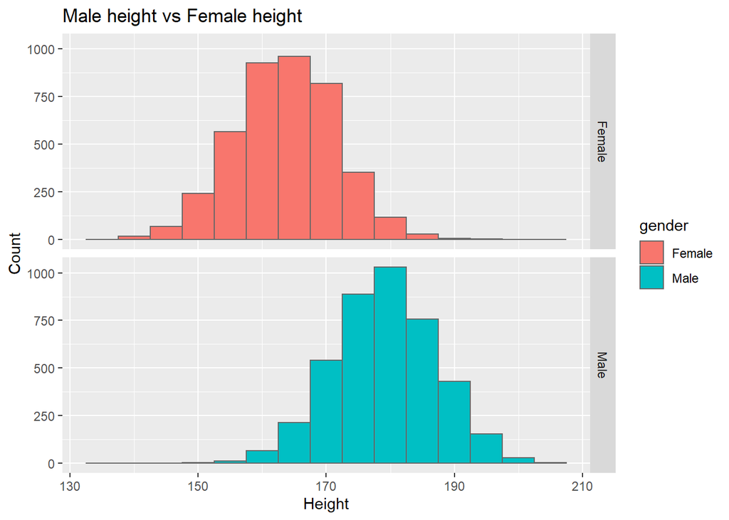

```r
ggplot(students, aes(students$height, fill=gender)) +
  geom_histogram(position="identity", colour="grey40", binwidth=5) +
  facet_grid(gender ~ .) +
  ggtitle("Male height vs Female height") +
  xlab("Height") +
  ylab("Count")
```

Students height looks to be symmetric normal distribution, but in order to be sure enough we will use qqnorm and qqline functions.

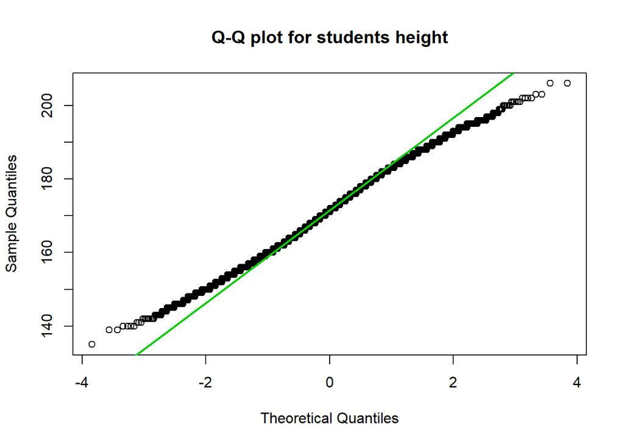

```r
qqnorm(students$height, main="Q-Q plot for students height")
qqline(students$height, col=3, lwd=2)
```

By examining the plot we can see there is divergence in upper tail and lower tail of the graph, so we will examine it further by taking the subset of data in to male and female.

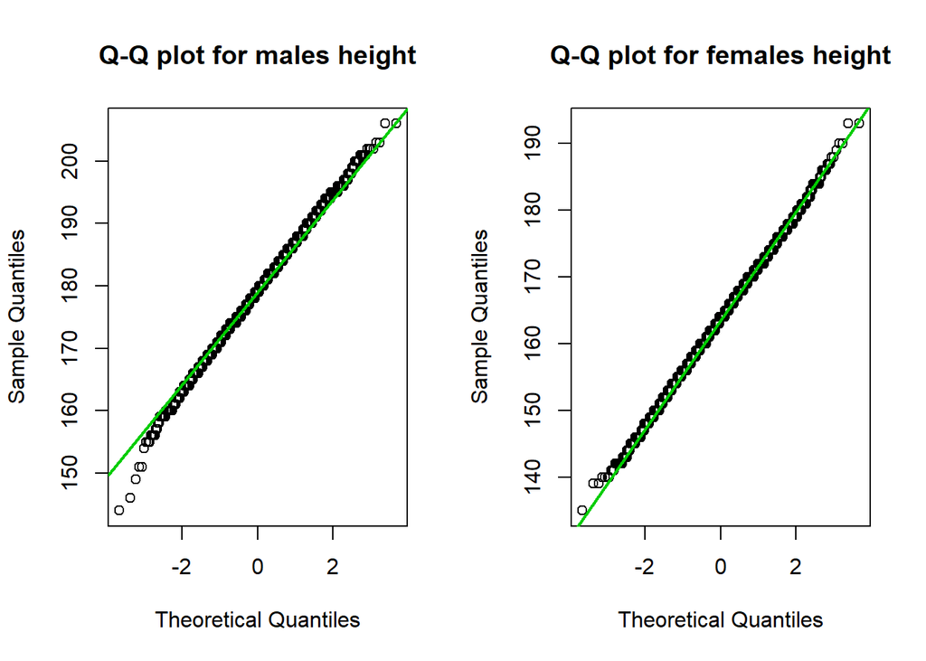

```r
males <- subset(students, gender=="Male")
females <- subset(students, gender=="Female")
par(mfrow=c(1, 2))
qqnorm(males$height, main="Q-Q plot for males height")
qqline(males$height, col=3, lwd=2)

qqnorm(females$height, main="Q-Q plot for females height")
qqline(females$height, col=3, lwd=2)
```

Now we are sure that the height of male and female students are symmetric normal distribution, for better understanding We will have a look at summary and the standard deviation of student’s heights.

```r
summary(males$height)
```

```
##    Min. 1st Qu.  Median    Mean 3rd Qu.    Max.
##   144.0   174.0   179.0   179.1   184.0   206.0
```

```r
sd(males$height)
```

```
## [1] 7.988852
```

```r
summary(females$height)
```

```
##    Min. 1st Qu.  Median    Mean 3rd Qu.    Max.
##   135.0   158.0   164.0   163.7   169.0   193.0
```

```r
sd(females$height)
```

```
## [1] 7.919726
```

We can use boxplot in order to check if there is any outlier or not.

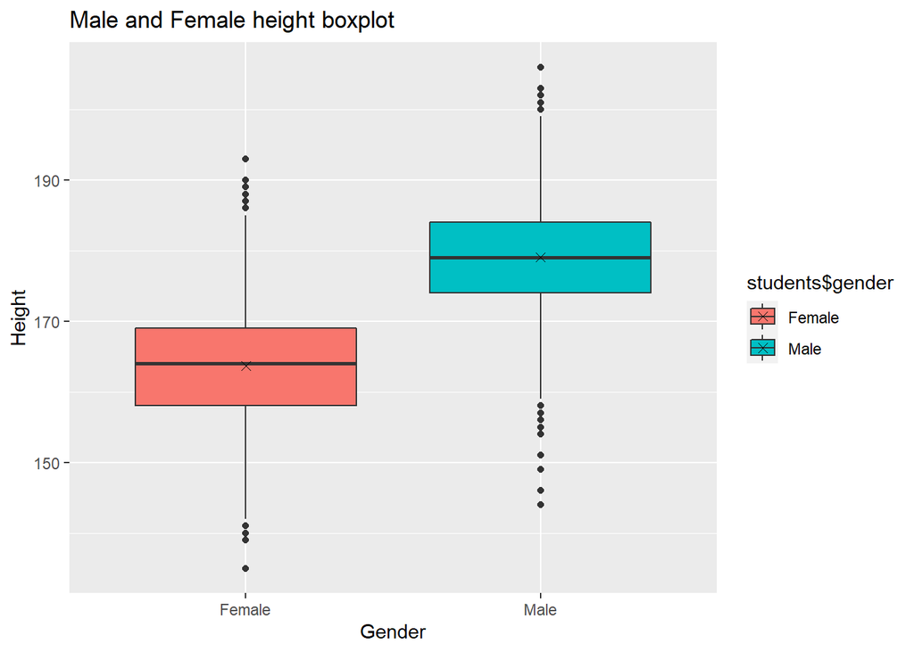

```r
ggplot(data=students, aes(x=students$gender, y=students$height, fill=students$gender)) +
  geom_boxplot() +
  labs(title = "Male and Female height boxplot", x = "Gender", y="Height") +
  stat_summary(fun.y=mean, geom="point", shape=4, size=2)
```

The above boxplot shows there are outliers both in male and female students height.

#### Analyzing Students Weight

```r
summary(males$weight)
```

```
##    Min. 1st Qu.  Median    Mean 3rd Qu.    Max.
##   56.90   73.20   77.90   78.59   83.20  116.00
```

```r
summary(females$weight)
```

```
##    Min. 1st Qu.  Median    Mean 3rd Qu.    Max.
##   51.40   63.70   67.00   67.38   70.60   93.80
```

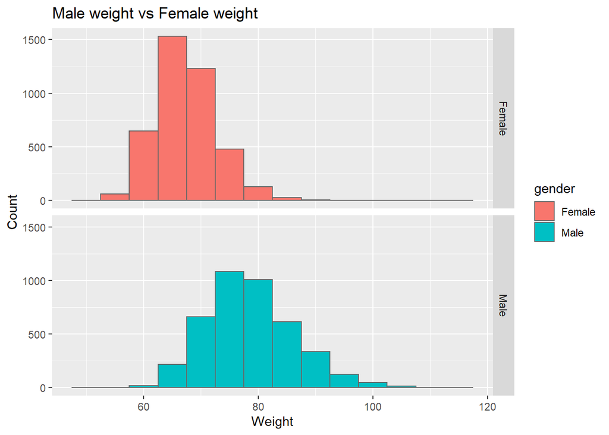

```r
ggplot(students, aes(students$weight, fill=gender)) +
  geom_histogram(position="identity", colour="grey40", binwidth=5) +
  facet_grid(gender ~ .) +
  ggtitle("Male weight vs Female weight") +
  xlab("Weight") +
  ylab("Count")
```

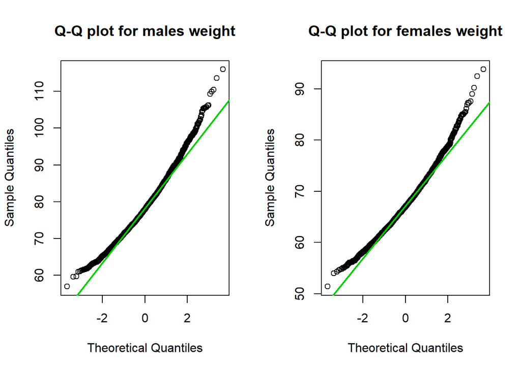

```r
par(mfrow=c(1, 2))
qqnorm(males$weight, main="Q-Q plot for males weight")
qqline(males$weight, col=3, lwd=2)

qqnorm(females$weight, main="Q-Q plot for females weight")
qqline(females$weight, col=3, lwd=2)
```

#### Analyzing student’s religion

```r
summary(religion)
```

```
##   Catholic     Muslim   Orthodox      Other Protestant
##       2797        330        585       2688       1839
```

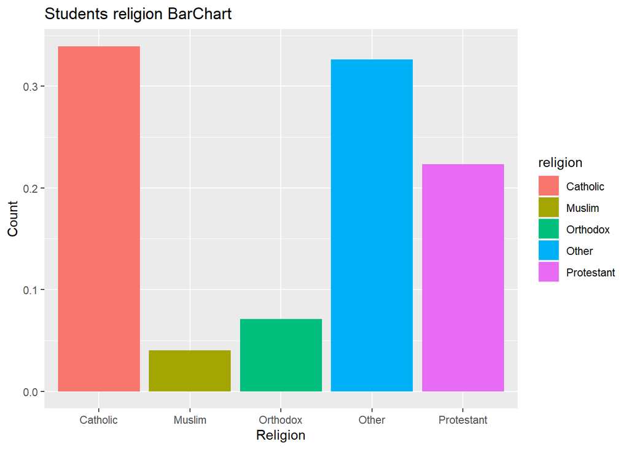

```r
ggplot(students, aes(x=religion, fill=religion))+
  geom_bar(aes(y = (..count..)/sum(..count..))) +
  labs(title = "Students religion BarChart",x= "Religion",y= "Count")
```

Catholic religion has the most followers between students.

#### Analyzing student’s nc.Score

```r
summary(nc.score)
```

```
##    Min. 1st Qu.  Median    Mean 3rd Qu.    Max.
##   1.000   1.460   2.040   2.166   2.780   4.000
```

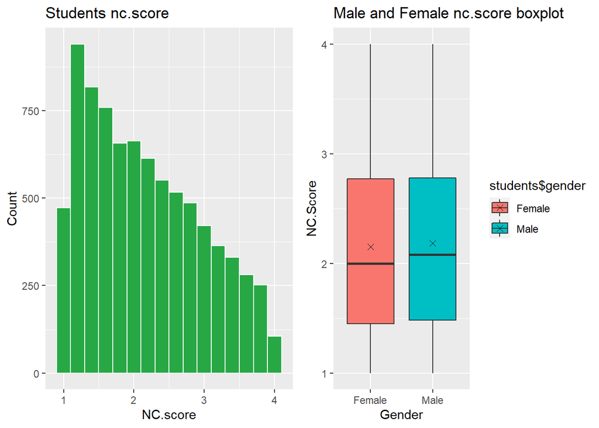

```r
plot1 <- ggplot(students, aes(x=nc.score)) +
  geom_histogram(binwidth = 0.2, colour="white", fill="#28a745") +
  labs(title = "Students nc.score", x="NC.score", y="Count")

plot2 <- ggplot(data=students, aes(x=students$gender, y=students$nc.score, fill=students$gender)) +
  geom_boxplot() +
  labs(title = "Male and Female nc.score boxplot", x = "Gender", y="NC.Score") +
  stat_summary(fun.y=mean, geom="point", shape=4, size=2)
grid.arrange(plot1, plot2, ncol=2)
```

Students nc.score is asymmetric and skewed to the right

#### Analyzing student’s Semester

```r
summary(semester)
```

```
## >6th  1st  2nd  3rd  4th  5th  6th
##  303 1709 1638 1641 1368  876  704
```

The summary of semester shows there is a problem in data, the 6th semester is written in two ways “>6th” and “6th”.  
The problem can be solved by the following code:

```r
students$semester[students$semester == ">6th"] <- "6th"
summary(students$semester)
```

```
## >6th  1st  2nd  3rd  4th  5th  6th
##    0 1709 1638 1641 1368  876 1007
```

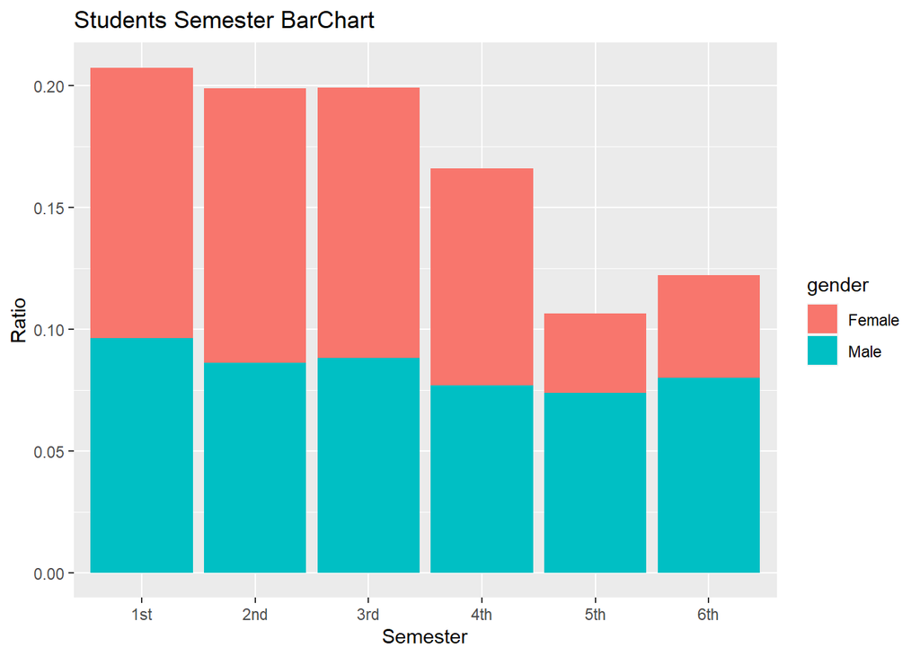

```r
ggplot(students, aes(x=semester, fill=gender))+
  geom_bar(aes(y = (..count..)/sum(..count..))) +
  labs(title = "Students Semester BarChart",x= "Semester",y= "Ratio")
```

The above Barchart shows more than 60% of students are in 1st, 2nd and 3rd semesters.

#### Analyzing student’s Major

```r
summary(students$major)
```

```
##                    Biology      Economics and Finance
##                       1597                       1324
##     Environmental Sciences Mathematics and Statistics
##                       1626                       1225
##          Political Science            Social Sciences
##                       1455                       1012
```

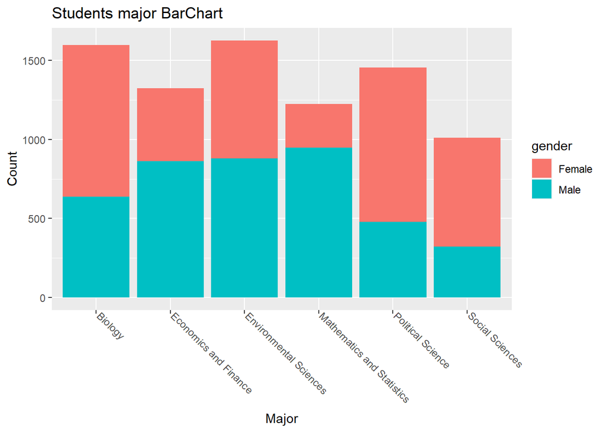

```r
ggplot(students, aes(x=major, fill=gender))+
  geom_bar() +
  labs(title = "Students major BarChart",x= "Major",y= "Count") +
  theme(axis.text.x=element_text(angle=-45,hjust=0,vjust=0))
```

From above graph one can easily conclude that Environmental science and Biology faculties have the most students among other, also females are more than males in Biology and Political science faculties and males are more than females in ‘Economics and Finance’ and ‘Mathematics and statistics’ faculties and …

#### Analyzing student’s Minor

```r
summary(students$minor)
```

```
##                    Biology      Economics and Finance
##                       1318                       1382
##     Environmental Sciences Mathematics and Statistics
##                       1318                       1446
##          Political Science            Social Sciences
##                       1387                       1388
```

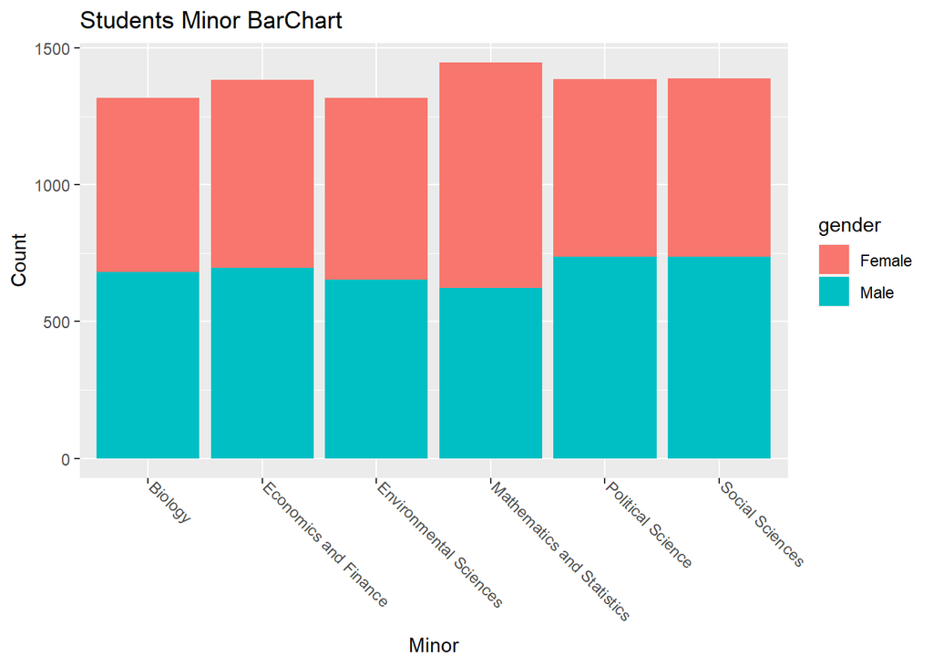

```r
ggplot(students, aes(x=minor, fill=gender))+
  geom_bar() +
  labs(title = "Students Minor BarChart",x= "Minor",y= "Count") +
  theme(axis.text.x=element_text(angle=-45,hjust=0,vjust=0))
```

The above Barchart shows Students are uniformly distributed.

#### Analyzing student’s Score1

```r
summary(students$score1)
```

```
##    Min. 1st Qu.  Median    Mean 3rd Qu.    Max.    NA's
##   30.00   58.00   70.00   68.17   78.00   97.00    3347
```

The above summary shows there are 3347 Empty cells for score1. Therefore, I will take subset of students based on their major for better analyzing.

```r
students.math <- subset(students, major=="Mathematics and Statistics")
cat("Number of students in Mathematics and Statistics faculty:",length(students.math[,1]))
```

```
## Number of students in Mathematics and Statistics faculty: 1225
```

```r
cat("Number of students who do not have score1:",length(students.math$score1[is.na(students.math$score1)]))
```

```
## Number of students who do not have score1: 478
```

```r
cat("Number of students who have score1:",length(students.math$score1[!is.na(students.math$score1)]))
```

```
## Number of students who have score1: 747
```

```r
summary(students.math$score1)
```

```
##    Min. 1st Qu.  Median    Mean 3rd Qu.    Max.    NA's
##   78.00   86.00   88.00   88.09   90.00   97.00     478
```

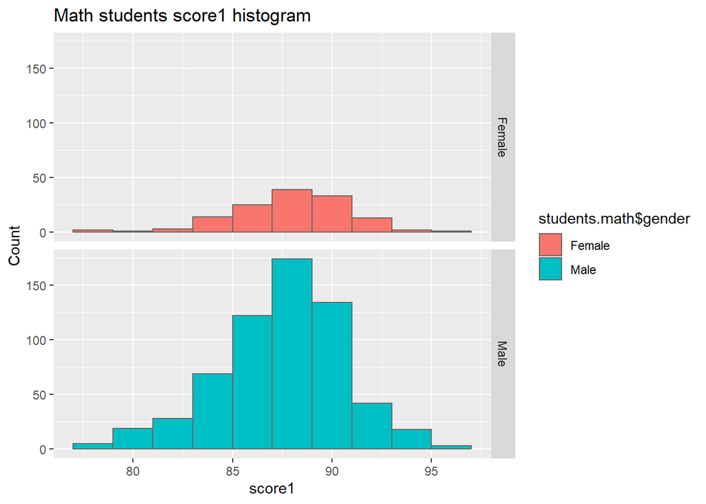

```r
ggplot(students.math, aes(students.math$score1, fill=students.math$gender)) +
  geom_histogram(position="identity", colour="grey40", binwidth=2) +
  facet_grid(students.math$gender ~ .)+
  labs(title="Math students score1 histogram", x ="score1", y="Count")
```

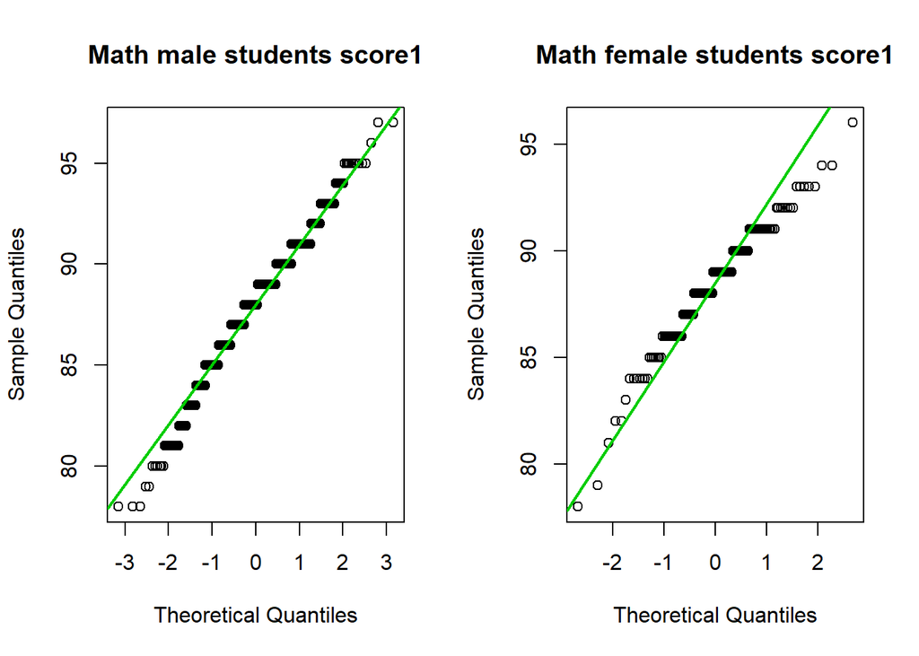

```r
par(mfrow=c(1, 2))
qqnorm(students.math$score1[students.math$gender=="Male"],
       main="Math male students score1")
qqline(students.math$score1[students.math$gender=="Male"], col=3, lwd=2)

qqnorm(students.math$score1[students.math$gender=="Female"],
       main="Math female students score1")
qqline(students.math$score1[students.math$gender=="Female"], col=3, lwd=2)
```

The above histogram and Q-Q plot shows students score1 is roughly symmetric and great portion of student’s score1 lies between 83-91.

#### Analyzing student’s graduated variable

```r
table(graduated)
```

```
## graduated
##    0    1
## 6486 1753
```

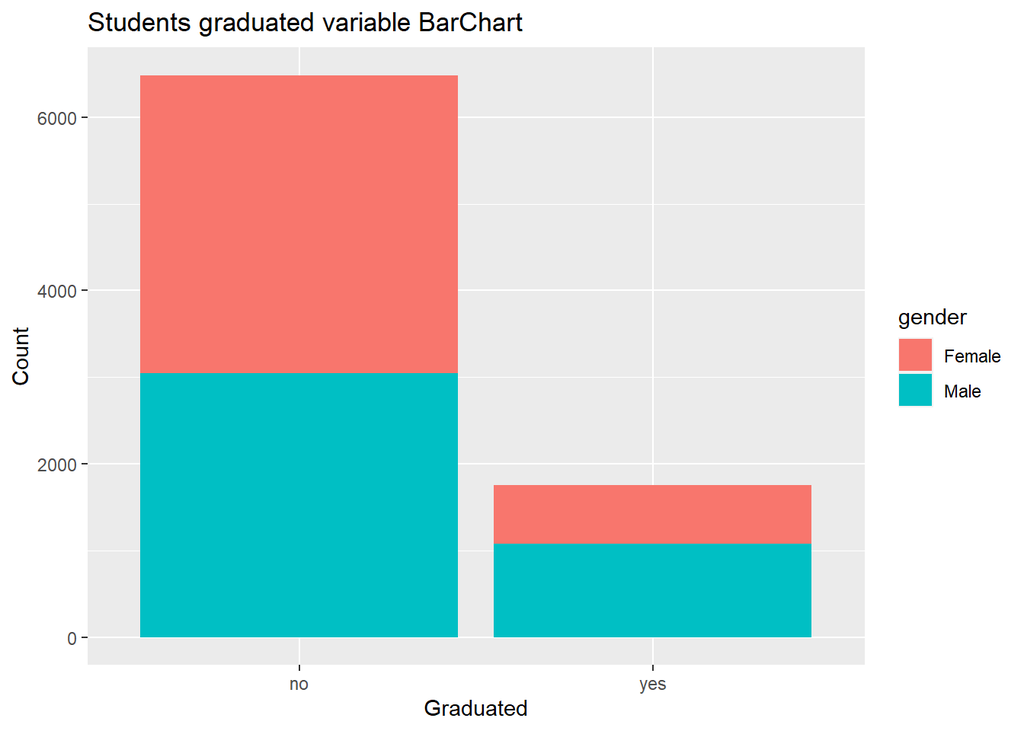

```r
ggplot(students, aes(x=as.factor(graduated), fill=gender))+
  geom_bar() +
  labs(title = "Students graduated variable BarChart",x= "Graduated",y= "Count")
```

The above Barchart shows most of graduated students are male and most of students who are still studying are females.

#### Analyzing student’s Salary Variable

```r
summary(salary)
```

```
##    Min. 1st Qu.  Median    Mean 3rd Qu.    Max.    NA's
##   11444   35207   41672   42522   49373   75597    6486
```

The summary shows there are 6486 rows in Salary variable which are empty. I will take the subset of students who have salary and I will plot the histogram, density histogram and qqplot of salary for further analyzing.

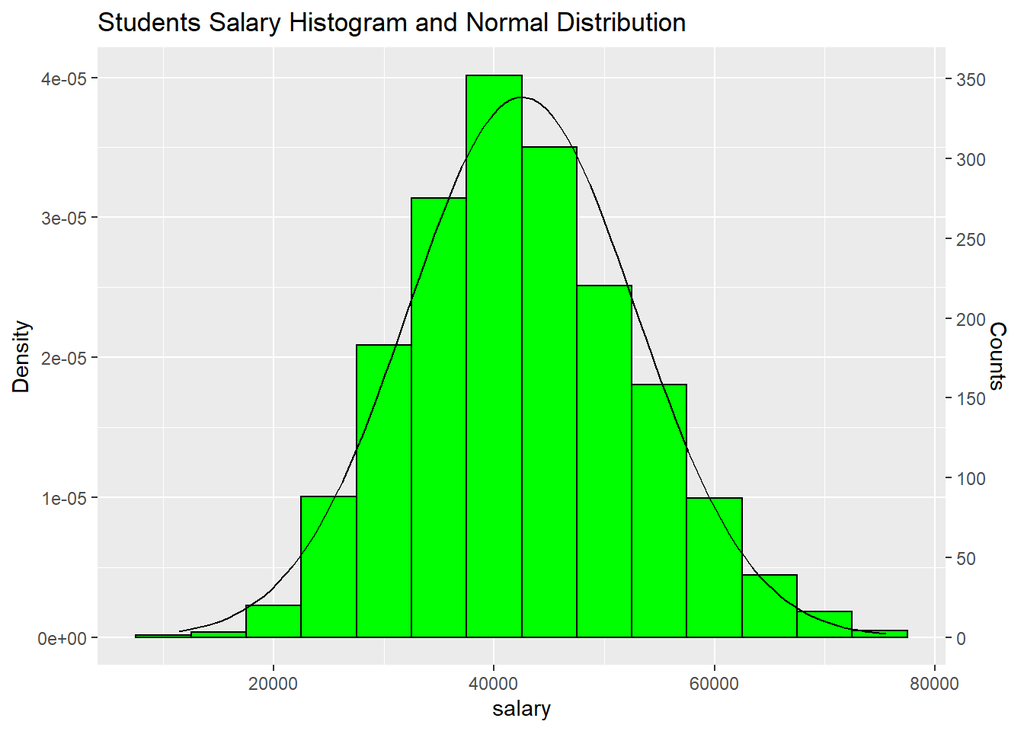

```r
students.salary <- students[!is.na(students$salary),]

# Set desired binwidth and number of non-missing obs
bw = 5000
n_obs = sum(!is.na(students.salary$salary))

g <- ggplot(students.salary, aes(x=salary)) +
  geom_histogram(aes(y=..density..), binwidth = bw, colour="black", fill="green")+
  stat_function(fun=dnorm, args = list(mean = mean(students.salary$salary), sd = sd(students.salary$salary))) +
  ggtitle("Students Salary Histogram and Normal Distribution")


ybreaks = seq(0,350,50)

## On primary axis and secondary axix
g + scale_y_continuous("Counts", breaks = round(ybreaks / (bw * n_obs),3), labels = ybreaks) +
  scale_y_continuous("Density", sec.axis = sec_axis(
  trans = ~ . * bw * n_obs, name = "Counts", breaks = ybreaks))
```

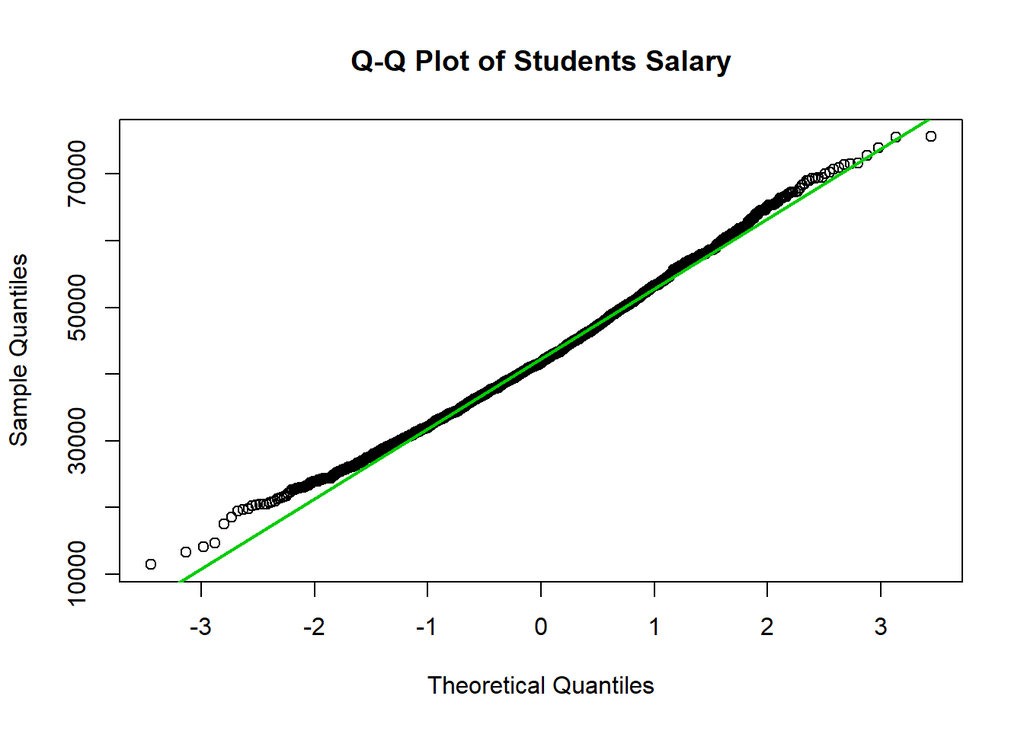

```r
qqnorm(students.salary$salary, main = "Q-Q Plot of Students Salary")
qqline(students.salary$salary, col=3, lwd=2)
```

#### Analyzing correlation between Student’s n.score and salary

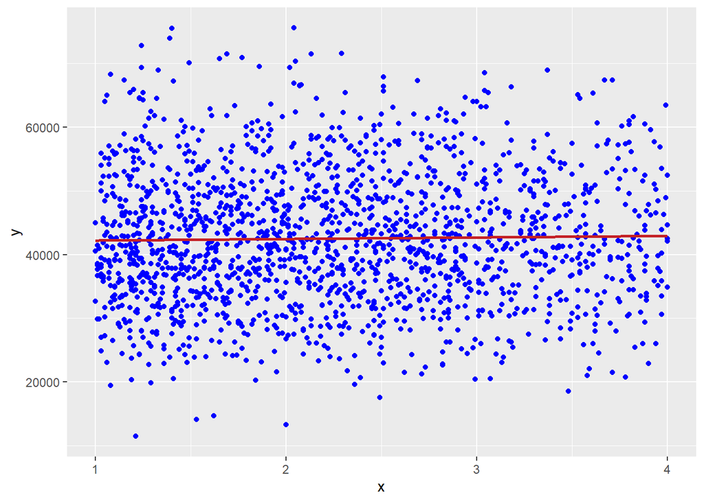

```
##  The Correlation Coefficient:  0.0189558417515911
##  Evaluation Result:  Weak Positive Relationship
```

```r
# define function
correlation.analyzer <- function(data, x, y) {
  print(
    ggplot(data = data, aes(x = x, y = y)) +
      geom_point(color = 'blue') +
      geom_smooth(
        method = lm,
        se
        = FALSE,
        fullrange = TRUE,
        col = "#C42126"
      )
  )

  cor.val <- cor(x, y, method = 'pearson')
  if (cor.val > 0.7) {
    result <- "Strong Positive Relationship"
  } else if (cor.val > 0.3) {
    result <- "Moderate Positive Relationship"
  } else if (cor.val > 0) {
    result <- "Weak Positive Relationship"
  } else if (cor.val > -0.3) {
    result <- "Weak Negative Relationship"
  } else if (cor.val > -0.7) {
    result <- "Moderate Negative Relationship"
  } else if (cor.val >= -1) {
    result <- "Strong Negative Relationship"
  }
  return(cat(
    paste(
      " The Correlation Coefficient: ",
      cor.val,
      "\n",
      "Evaluation Result: ",
      result,
      "\n",
      sep = " "
    )
  ))
}


correlation.analyzer(students.salary,
                     students.salary$nc.score,
                     students.salary$salary
                     )
```

The figure shows there is no correlation between students n.score and salary.

#### Analyzing correlation between Student’s score1 and salary

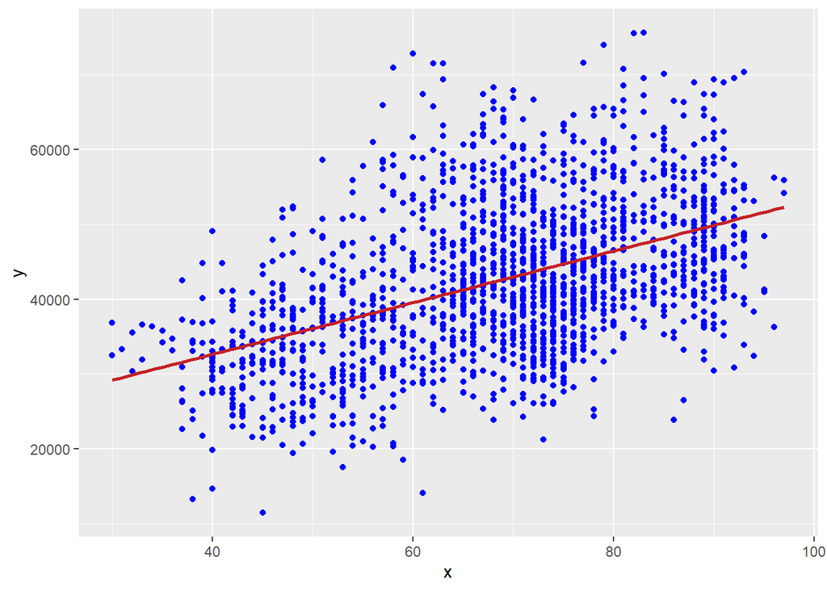

```
##  The Correlation Coefficient:  0.470997361701785
##  Evaluation Result:  Moderate Positive Relationship
```

```r
correlation.analyzer(students.salary,
                     students.salary$score1,
                     students.salary$salary
                     )
```

#### Analyzing correlation between Student’s score2 and salary

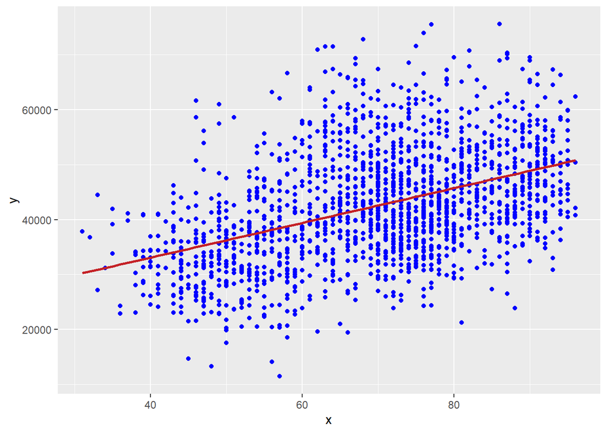

```
##  The Correlation Coefficient:  0.440388281182651
##  Evaluation Result:  Moderate Positive Relationship
```

```r
correlation.analyzer(students.salary,
                     students.salary$score2,
                     students.salary$salary
                     )
```

```r
# Remove unnecessary variables
rm(g, plot1, plot2, students.math, students.salary, bw, n_obs, ybreaks, correlation.analyzer)
```

#### 2. (10p) Find confidence intervals for nc.score, score1 and score2 evaluating the differences based on gender. Use gglot2 to plot the corresponding confidence intervals to support your evaluations.

Let’s start by calculating confidence interval for numerous clauses of students based on gender.

```r
# calculating confidence interval for male students nc.score
x <- t.test(males$nc.score)$conf.int
x
```

```
## [1] 2.158372 2.207470
## attr(,"conf.level")
## [1] 0.95
```

The above output indicates that the true average of numerous clauses for male students is between 2.16 and 2.21 with 95% confidence.

```r
# calculating confidence interval for females nc.score
y <- t.test(females$nc.score)$conf.int
y
```

```
## [1] 2.124944 2.174988
## attr(,"conf.level")
## [1] 0.95
```

Also the above output indicates that the true average of numerous clauses for female students is between 2.12 and 2.17 with 95% confidence.

Here is how it looks like when we visualize it.

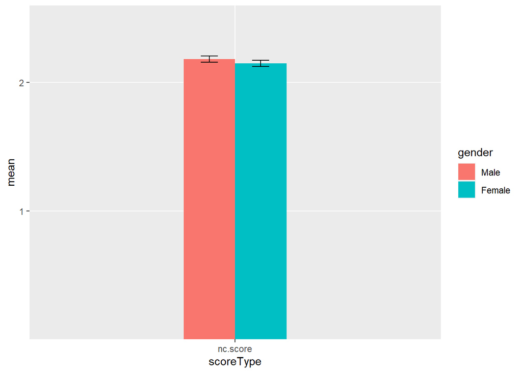

```r
students.nc.score <- data.frame(gender="Male",
                                scoreType="nc.score",
                                mean=mean(males$nc.score),
                                lower=x[1],
                                upper=x[2])

students.nc.score <- rbind(students.nc.score, data.frame(gender="Female",
                                scoreType="nc.score",
                                mean=mean(females$nc.score),
                                lower=y[1],
                                upper=y[2]))

ggplot(students.nc.score, aes(x=scoreType, y=mean, fill=gender)) +
  geom_bar(position="dodge", stat="identity", width = 0.3) +
  scale_y_discrete(limit=c(seq(1, 2.5))) +
  geom_errorbar(aes(ymin=lower, ymax=upper),
                width=.1, # Width of the error bars
                position=position_dodge(0.3))
```

Now let’s calculate confidence interval for score1 of students based on gender.

```r
males.score1 = subset(males, !is.na(score1))
females.score1 = subset(females, !is.na(score1))

# calculating confidence interval for male students score1
x <- t.test(males.score1$score1)$conf.int
x
```

```
## [1] 70.65008 71.68427
## attr(,"conf.level")
## [1] 0.95
```

The above output indicates that the true average of score1 for male students is between 70.65 and 71.68 with 95% confidence.

```r
# calculating confidence interval for female students score1
y <- t.test(females.score1$score1)$conf.int
y
```

```
## [1] 64.11471 65.25687
## attr(,"conf.level")
## [1] 0.95
```

Also the above output indicates that the true average of score1for female students is between 64.11 and 65.26 with 95% confidence.

To conclude, It looks there is no overlap between males and females score1 confidence interval and it’s a clue that the difference may be significant, but we cannot be sure. We must to perform statistical test to draw a conclusion.

Here is how it looks like when we visualize it.

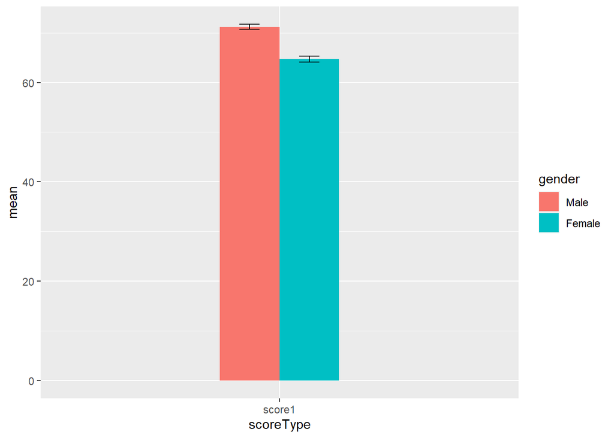

```r
students.score1 <- data.frame(gender="Male",
                                scoreType="score1",
                                mean=mean(males.score1$score1),
                                lower=x[1],
                                upper=x[2])

students.score1 <- rbind(students.score1, data.frame(gender="Female",
                                scoreType="score1",
                                mean=mean(females.score1$score1),
                                lower=y[1],
                                upper=y[2]))

ggplot(students.score1, aes(x=scoreType, y=mean, fill=gender)) +
  geom_bar(position="dodge", stat="identity", width = 0.3) +
  geom_errorbar(aes(ymin=lower, ymax=upper),
                width=.1, # Width of the error bars
                position=position_dodge(0.3))
```

Lastly, let’s calculate confidence interval for score2 of students based on gender.

```r
males.score2 = subset(males, !is.na(score2))
females.score2 = subset(females, !is.na(score2))

# calculating confidence interval for male students score1
x <- t.test(males.score2$score2)$conf.int
x
```

```
## [1] 71.86225 72.92831
## attr(,"conf.level")
## [1] 0.95
```

The above output indicates that the true average of score2 for male students is between 71.86 and 72.93 with 95% confidence.

```r
# calculating confidence interval for female students score1
y <- t.test(females.score2$score2)$conf.int
y
```

```
## [1] 65.54846 66.71809
## attr(,"conf.level")
## [1] 0.95
```

Also the above output indicates that the true average of score2 for female students is between 65.55 and 66.72 with 95% confidence.

To conclude, It looks again there is no overlap between males and females score2 confidence interval and it’s a clue that the difference may be significant, but we cannot be sure. We must to perform statistical test to draw a conclusion.

Here is how it looks like when we visualize it.

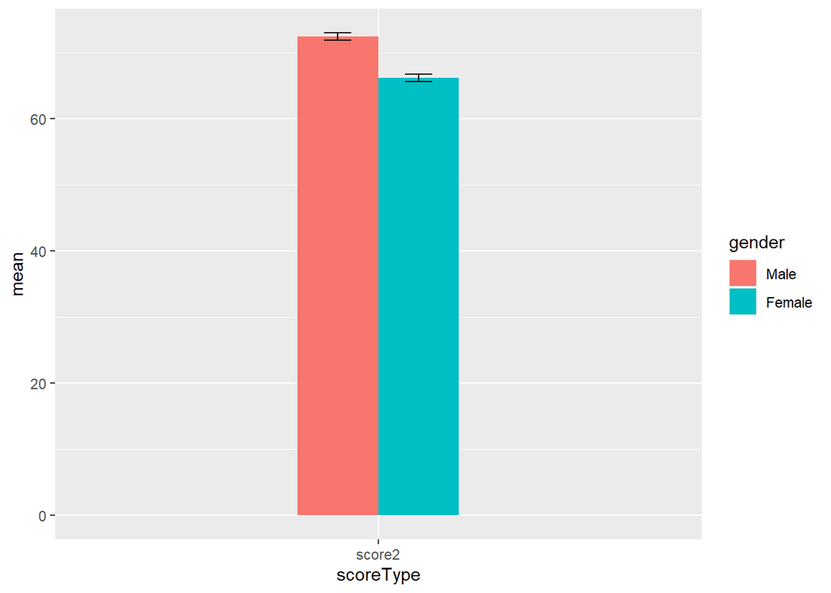

```r
students.score2 <- data.frame(gender="Male",
                                scoreType="score2",
                                mean=mean(males.score2$score2),
                                lower=x[1],
                                upper=x[2])

students.score2 <- rbind(students.score2, data.frame(gender="Female",
                                scoreType="score2",
                                mean=mean(females.score2$score2),
                                lower=y[1],
                                upper=y[2]))

ggplot(students.score2, aes(x=scoreType, y=mean, fill=gender)) +
  geom_bar(position="dodge", stat="identity", width = 0.3) +
  geom_errorbar(aes(ymin=lower, ymax=upper),
                width=.1, # Width of the error bars
                position=position_dodge(0.3))
```

#### 3. (10p) Find confidence intervals for salary evaluate the differences based on gender, religion and major. Use gglot2 to plot the corresponding confidence intervals to support your evaluations.

In order to find confidence interval of salary for students based on gender, first we need to get the subset of male and female students who have salary. Then we will calculate confidence interval.

```r
# Get the subset of males and females students where its salary is not null
males.salary = subset(males, !is.na(salary))
females.salary = subset(females, !is.na(salary))

# calculating confidence interval for male students salary
x <- t.test(males.salary$salary)$conf.int
x
```

```
## [1] 46007.74 47161.53
## attr(,"conf.level")
## [1] 0.95
```

The above output indicates that the true average of salary for male students is between 46007 and 47161 with 95% confidence.

```r
# calculating confidence interval for female students salary
y <- t.test(females.salary$salary)$conf.int
y
```

```
## [1] 35433.89 36603.03
## attr(,"conf.level")
## [1] 0.95
```

Also the above output indicates that the true average of salary for female students is between 35433 and 36603 with 95% confidence.

To conclude, It looks there is no overlap between males and females salary confidence interval and it’s a clue that the difference may be significant, but we cannot be sure. We must to perform statistical test to draw a conclusion.

Here is how it looks like when we visualize it.

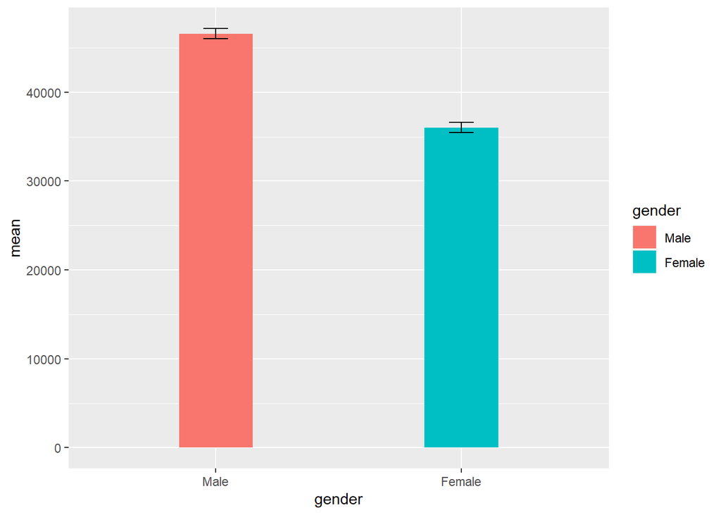

```r
students.salary <- data.frame(gender="Male",
                                mean=mean(males.salary$salary),
                                lower=x[1],
                                upper=x[2])

students.salary <- rbind(students.salary, data.frame(gender="Female",
                                mean=mean(females.salary$salary),
                                lower=y[1],
                                upper=y[2]))

ggplot(students.salary, aes(x=gender, y=mean, fill=gender)) +
  geom_bar(position="dodge", stat="identity", width = 0.3) +
  geom_errorbar(aes(ymin=lower, ymax=upper),
                width=.1, # Width of the error bars
                position=position_dodge(0.1))
```

Now we will calculate confidence interval for students salary based on religion.

```r
# Get the subset of students who have salary
students.salary <- subset(students, !is.na(salary))

# Get the subset of students whose religion is Catholic
students.catholic <- subset(students.salary, religion=="Catholic")

# calculating confidence interval for Catholic students salary
a <- t.test(students.catholic$salary)$conf.int
a
```

```
## [1] 41888.38 43495.91
## attr(,"conf.level")
## [1] 0.95
```

The above output indicates that the true average of salary for Catholic students is between 41888 and 43495 with 95% confidence.

```r
# Get the subset of students whose religion is Muslim
students.muslim <- subset(students.salary, religion=="Muslim")

# calculating confidence interval for Muslim students salary
b <- t.test(students.muslim$salary)$conf.int
b
```

```
## [1] 38335.16 42584.83
## attr(,"conf.level")
## [1] 0.95
```

Also the above output indicates that the true average of salary for Muslim students is between 38335 and 42584 with 95% confidence.

```r
# Get the subset of students whose religion is Orthodox
students.orthodox <- subset(students.salary, religion=="Orthodox")

# calculating confidence interval for Orthodox students salary
c <- t.test(students.orthodox$salary)$conf.int
c
```

```
## [1] 40207.93 43850.48
## attr(,"conf.level")
## [1] 0.95
```

Further more, the above output indicates that the true average of salary for Orthodox students is between 40207 and 43850 with 95% confidence.

```r
# Get the subset of students whose religion is Protestant
students.protestant <- subset(students.salary, religion=="Protestant")

# calculating confidence interval for Protestant students salary
d <- t.test(students.protestant$salary)$conf.int
d
```

```
## [1] 41890.48 44036.02
## attr(,"conf.level")
## [1] 0.95
```

Further more, the above output indicates that the true average of salary for Protestant students is between 41890 and 44036 with 95% confidence.

```r
# Get the subset of students whose religion is Other
students.other <- subset(students.salary, religion=="Other")

# calculating confidence interval for students salary whose religion is other
e <- t.test(students.other$salary)$conf.int
e
```

```
## [1] 41509.05 43235.89
## attr(,"conf.level")
## [1] 0.95
```

Further more, the above output indicates that the true average of salary for students whose religion is other, is between 41509 and 43235 with 95% confidence.

To conclude, It looks there is overlap on confidence interval between students salary based on religion and it’s a clue that the difference is not statistically significant. We must actually perform a statistical test to draw a conclusion.

Here is how it looks like when we visualize it.

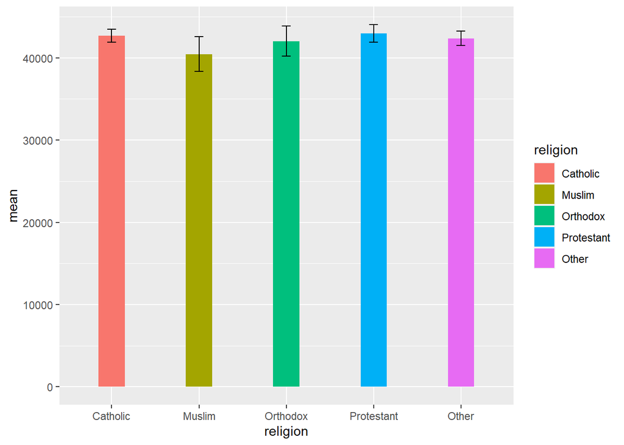

```r
students.salary <- data.frame(religion="Catholic",
                                mean=mean(students.catholic$salary),
                                lower=a[1],
                                upper=a[2])

students.salary <- rbind(students.salary, data.frame(religion="Muslim",
                                mean=mean(students.muslim$salary),
                                lower=b[1],
                                upper=b[2]))

students.salary <- rbind(students.salary, data.frame(religion="Orthodox",
                                mean=mean(students.orthodox$salary),
                                lower=c[1],
                                upper=c[2]))

students.salary <- rbind(students.salary, data.frame(religion="Protestant",
                                mean=mean(students.protestant$salary),
                                lower=d[1],
                                upper=d[2]))

students.salary <- rbind(students.salary, data.frame(religion="Other",
                                mean=mean(students.other$salary),
                                lower=e[1],
                                upper=e[2]))

ggplot(students.salary, aes(x=religion, y=mean, fill=religion)) +
  geom_bar(position="dodge", stat="identity", width = 0.3) +
  geom_errorbar(aes(ymin=lower, ymax=upper),
                width=.1, # Width of the error bars
                position=position_dodge(0.1))
```

#### Salary based on major

Lastly, let’s calculate confidence interval for salary based on major.

```r
# Get the subset of students who have salary
students.salary <- subset(students, !is.na(salary))

# Get the subset of students whose major is Biology
students.biology <- subset(students.salary, major=="Biology")

# calculating confidence interval for Biology students salary
a <- t.test(students.biology$salary)$conf.int
a
```

```
## [1] 46988.12 48897.54
## attr(,"conf.level")
## [1] 0.95
```

The above output indicates that the true average of salary for Biology students is between 46988 and 48897 with 95% confidence.

```r
# Get the subset of students whose major is Economics and Finance
students.economics <- subset(students.salary, major=="Economics and Finance")

# calculating confidence interval for Economics and Finance students salary
b <- t.test(students.economics$salary)$conf.int
b
```

```
## [1] 48722.70 50669.64
## attr(,"conf.level")
## [1] 0.95
```

Also the above output indicates that the true average of salary for Economics and Finance students is between 48722 and 50669 with 95% confidence.

```r
# Get the subset of students whose major is Environmental Sciences
students.environ <- subset(students.salary, major=="Environmental Sciences")

# calculating confidence interval for Environmental Sciences students salary
c <- t.test(students.environ$salary)$conf.int
c
```

```
## [1] 37048.04 38257.32
## attr(,"conf.level")
## [1] 0.95
```

Further more, the above output indicates that the true average of salary for Environmental Sciences students is between 37048 and 38257 with 95% confidence.

```r
# Get the subset of students whose major is Mathematics and statistics
students.math <- subset(students.salary, major=="Mathematics and Statistics")

# calculating confidence interval for Environmental Sciences students salary
d <- t.test(students.math$salary)$conf.int
d
```

```
## [1] 47474.44 49412.57
## attr(,"conf.level")
## [1] 0.95
```

```r
# Get the subset of students whose major is Political Science
students.politics <- subset(students.salary, major=="Political Science")

# calculating confidence interval for students salary whose major is Political Science
e <- t.test(students.politics$salary)$conf.int
e
```

```
## [1] 35322.59 37457.96
## attr(,"conf.level")
## [1] 0.95
```

Further more, the above output indicates that the true average of salary for Political Science students is between 35322 and 37457 with 95% confidence.

```r
# Get the subset of students whose major is Social Sciences
students.social <- subset(students.salary, major=="Social Sciences")

# calculating confidence interval for students salary whose major is Political Science
f <- t.test(students.social$salary)$conf.int
f
```

```
## [1] 31191.68 32896.33
## attr(,"conf.level")
## [1] 0.95
```

To conclude, it looks there are overlap on confidence interval between Biology, ‘Economics and Finance’ and ‘Mathematics and statistics’. It’s a clue that the difference is not statistically significant between them. However, we must actually perform a statistical test to draw a conclusion.

Also there is overlap on confidence interval between Environmental and Political science. It’s also a clue that the difference is not statistically significant and we must actually perform a statistical test to draw a conclusion.

Moreover, there is no overlap on confidence interval between Social science and other majors. It’s a clue that the difference may be significant, but we cannot be sure. We must actually perform a statistical test to draw a conclusion.

Here is how it looks like when we visualize it.

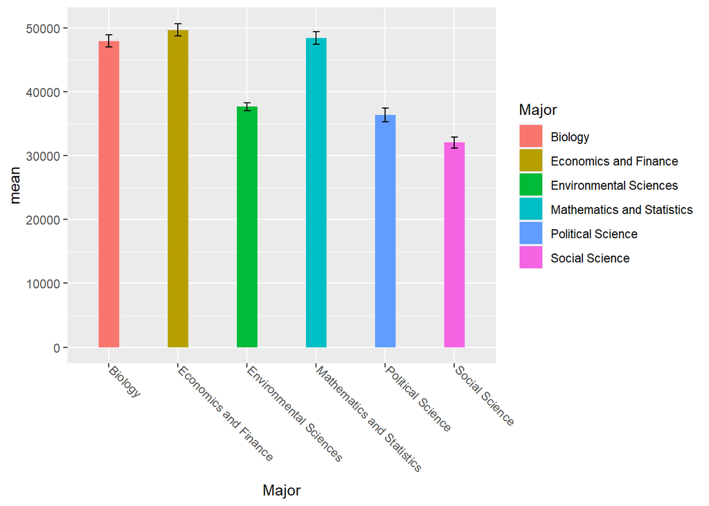

```r
students.salary <- data.frame(Major="Biology",
                                mean=mean(students.biology$salary),
                                lower=a[1],
                                upper=a[2])

students.salary <- rbind(students.salary, data.frame(Major="Economics and Finance",
                                mean=mean(students.economics$salary),
                                lower=b[1],
                                upper=b[2]))

students.salary <- rbind(students.salary, data.frame(Major="Environmental Sciences",
                                mean=mean(students.environ$salary),
                                lower=c[1],
                                upper=c[2]))

students.salary <- rbind(students.salary, data.frame(Major="Mathematics and Statistics",
                                mean=mean(students.math$salary),
                                lower=d[1],
                                upper=d[2]))

students.salary <- rbind(students.salary, data.frame(Major="Political Science",
                                mean=mean(students.politics$salary),
                                lower=e[1],
                                upper=e[2]))

students.salary <- rbind(students.salary, data.frame(Major="Social Science",
                                mean=mean(students.social$salary),
                                lower=f[1],
                                upper=f[2]))

ggplot(students.salary, aes(x=Major, y=mean, fill=Major)) +
  geom_bar(position="dodge", stat="identity", width = 0.3) +
  geom_errorbar(aes(ymin=lower, ymax=upper),
                width=.1, # Width of the error bars
                position=position_dodge(0.1)) +
  theme(axis.text.x=element_text(angle=-45,hjust=0,vjust=0))
```

#### 4. (10p) Create one sample hypothesis for mean salary and score1 for women and test it in 95% confidence level.

##### One sample hypothesis for mean of female students salary

Let’s test if true average of female students salary is less than 35000 So the hypothesis is formulated as following: H0: mu = 35000 Ha: mu < 35000

The data are continues, and we assume the sample is a simple random sample. As the sample size is large enough the normality assumption is not important but for the sake of information we will assess the normality of the data. In order to assess normality of data, we can use qqplot and shampiro test.

```r
# Get subset of female students who have salary
females.salary = subset(females, !is.na(salary))

shapiro.test(females.salary$salary)
```

```
##
##  Shapiro-Wilk normality test
##
## data:  females.salary$salary
## W = 0.99787, p-value = 0.5636
```

As the p-value > 0.05, the null hypothesis is not rejected, so data is normally distributed.

Let’s visualize it using Q-Q Plot.

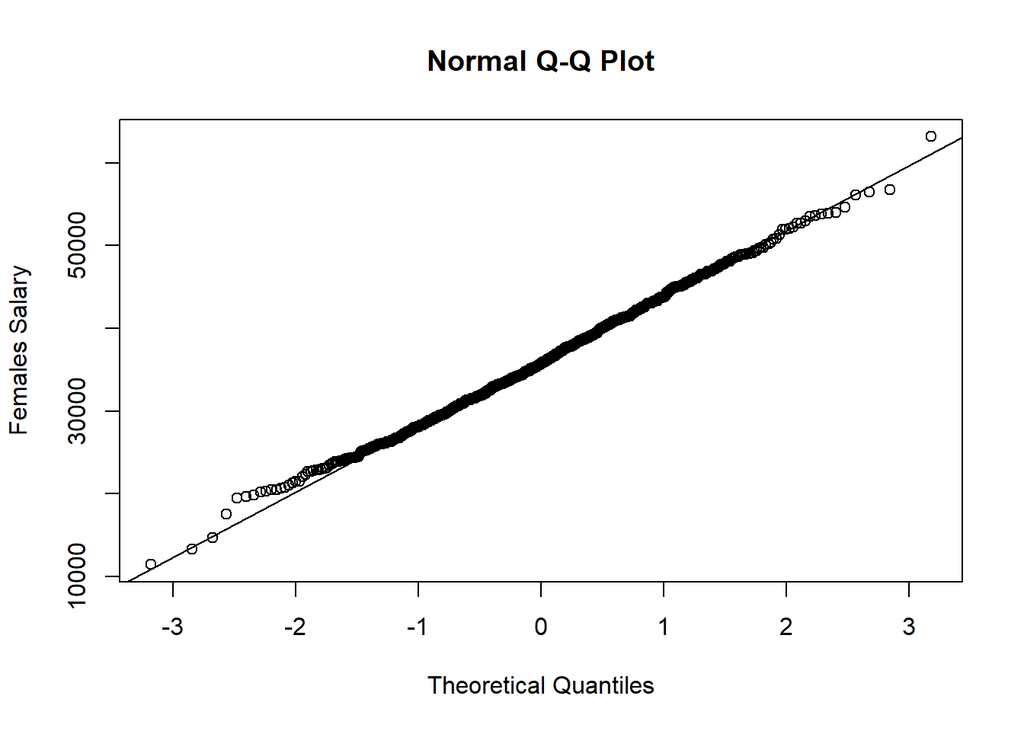

```r
qqnorm(females.salary$salary, ylab = "Females Salary")
qqline(females.salary$salary)
```

Now it is time to test the hypothesis.

```r
t.test(females.salary$salary,
       alternative = "less",
       mu=35000,
       conf.level = 0.95)
```

```
##
##  One Sample t-test
##
## data:  females.salary$salary
## t = 3.4209, df = 673, p-value = 0.9997
## alternative hypothesis: true mean is less than 35000
## 95 percent confidence interval:
##      -Inf 36508.84
## sample estimates:
## mean of x
##  36018.46
```

To conclude, as p-value = 0.9997 is greater than 0.05, the null hypothesis is not rejected. The confidence interval is between -infinity and 36508 with 95% confident.

##### One sample hypothesis for female students score1

Let’s test that the true average of female students score1 is not equal 64 So the hypothesis is formulated as following: H0: mu = 64 Ha: mu != 64

The data are continues, and we assume the sample is a simple random sample. As the sample size is large enough the normality assumption is not important but for the sake of information we will assess the normality. In order to assess normality of data, we can use qqplot and shampiro test.

```r
# Get subset of female students who have score1
females.score1 = subset(females, !is.na(score1))$score1

shapiro.test(females.score1)
```

```
##
##  Shapiro-Wilk normality test
##
## data:  females.score1
## W = 0.97164, p-value < 2.2e-16
```

As the p-value < 0.05, the null hypothesis is rejected, so data is not normally distributed.

Let’s visualize it using Q-Q Plot.

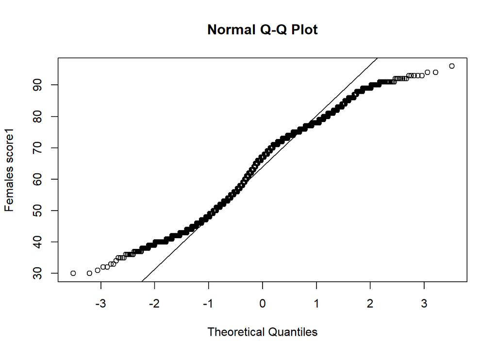

```r
qqnorm(females.score1, ylab = "Females score1")
qqline(females.score1)
```

Now it is time to test the hypothesis.

```r
t.test(females.score1,
       alternative = "two.sided",
       mu=64,
       conf.level = 0.95)
```

```
##
##  One Sample t-test
##
## data:  females.score1
## t = 2.3549, df = 2265, p-value = 0.01861
## alternative hypothesis: true mean is not equal to 64
## 95 percent confidence interval:
##  64.11471 65.25687
## sample estimates:
## mean of x
##  64.68579
```

To conclude, as p-value = 0.01861 is smaller than 0.05, the null hypothesis is rejected. The confidence interval is between 64.11 and 65.26 with 95% confident.

#### 5. (10p) Create two sample hypothesis for mean salary and score1 using gender as the grouping factor and test it in 95% confidence level.

##### Two sample hypothesis for salary based on gender

To start, it always helps to plot things!!!

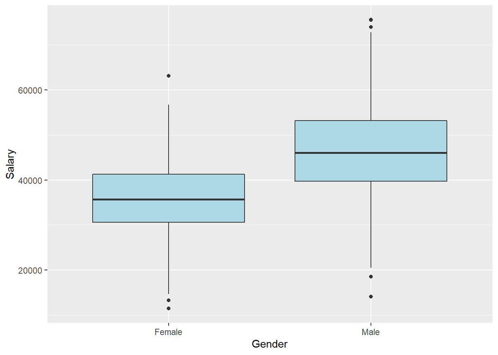

```r
# Get subset of students who have salary
sdata <- subset(students, !is.na(salary))

# Create boxplot showing how salaries varies based on gender
qplot(x = gender, y = salary,
      geom = "boxplot", data = sdata,
      xlab = "Gender",
      ylab = "Salary",
      fill = I("lightblue"))
```

This plot suggests that gender is associated with salary.

Let’s compute a summary table

```r
aggregate(salary ~ gender,
          data = sdata,
          FUN = function(x) {c(mean = mean(x),
                               se = sd(x) / sqrt(length(x)))})
```

```
##   gender salary.mean  salary.se
## 1 Female  36018.4616   297.7187
## 2   Male  46584.6338   294.0096
```

This difference is looking quite significant.

Let’s visualize it.

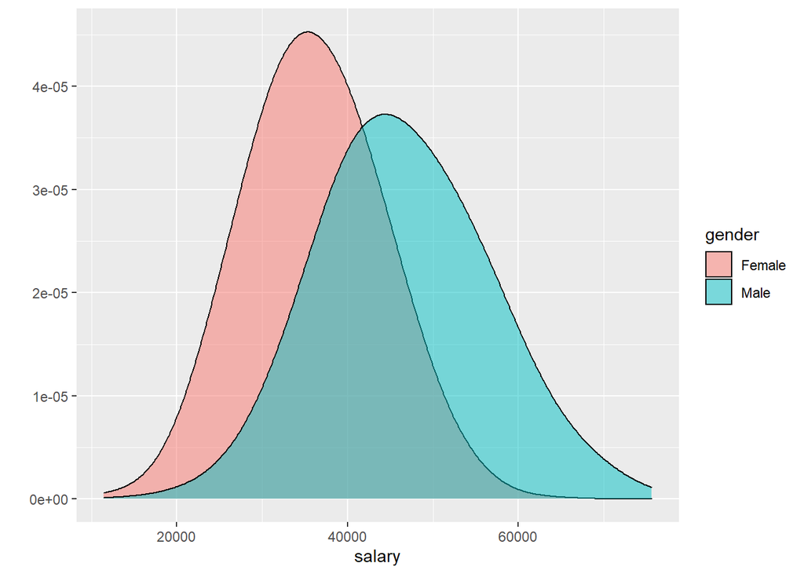

```r
# Density plots
qplot(fill = gender,
      x = salary,
      data = sdata,
      geom = "density",
      alpha = I(0.5),
      adjust = 2
      )
```

Let’s check if the populations have the same variance.

```r
x <- subset(sdata, gender=="Male")$salary
y <- subset(sdata, gender=="Female")$salary
var.test(x, y)
```

```
##
##  F test to compare two variances
##
## data:  x and y
## F = 1.5612, num df = 1078, denom df = 673, p-value = 3.535e-10
## alternative hypothesis: true ratio of variances is not equal to 1
## 95 percent confidence interval:
##  1.360876 1.787232
## sample estimates:
## ratio of variances
##           1.561249
```

As p-value < 0.05, the null hypothesis is rejected and the variances are not equal.

Checking assumptions: The two samples are random and independent. As the sample size is large enough, normality is not important. The variances are not the equal.

```r
t.test(x=x, y=y, alternative = "two.sided", var.equal = FALSE,
       conf.level = 0.95)
```

```
##
##  Welch Two Sample t-test
##
## data:  x and y
## t = 25.252, df = 1647.5, p-value < 2.2e-16
## alternative hypothesis: true difference in means is not equal to 0
## 95 percent confidence interval:
##   9745.475 11386.870
## sample estimates:
## mean of x mean of y
##  46584.63  36018.46
```

To conclude, as p-value < 0.05, the null hypothesis is rejected. We can conclude that there is statistically significant difference between male and female students salary.

```r
rm(females, males, sdata, x, y)
```

##### Two sample hypothesis for score1 based on gender

To start, it always helps to plot things!!!

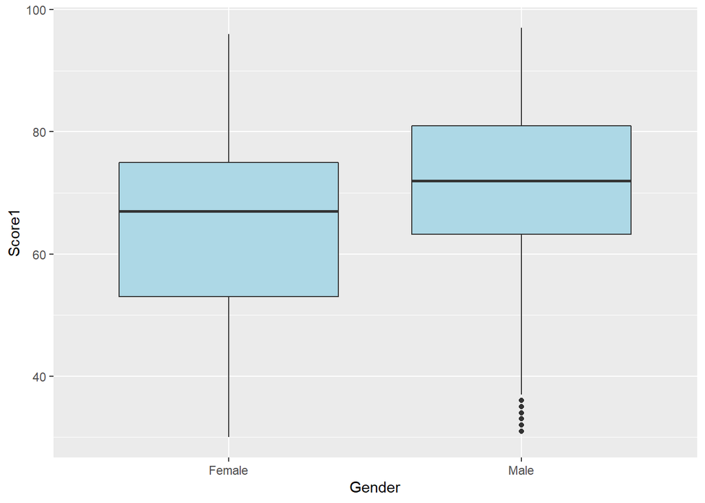

```r
# Get subset of students who have score1
sdata <- subset(students, !is.na(score1))

# Create boxplot showing how score1 varies based on gender
qplot(x = gender, y = score1,
      geom = "boxplot", data = sdata,
      xlab = "Gender",
      ylab = "Score1",
      fill = I("lightblue"))
```

This plot suggests that gender is associated with score1.

Let’s compute a summary table

```r
aggregate(salary ~ gender,
          data = sdata,
          FUN = function(x) {c(mean = mean(x),
                               se = sd(x) / sqrt(length(x)))})
```

```
##   gender salary.mean  salary.se
## 1 Female  36018.4616   297.7187
## 2   Male  46584.6338   294.0096
```

This difference is looking quite significant.

Let’s visualize it.

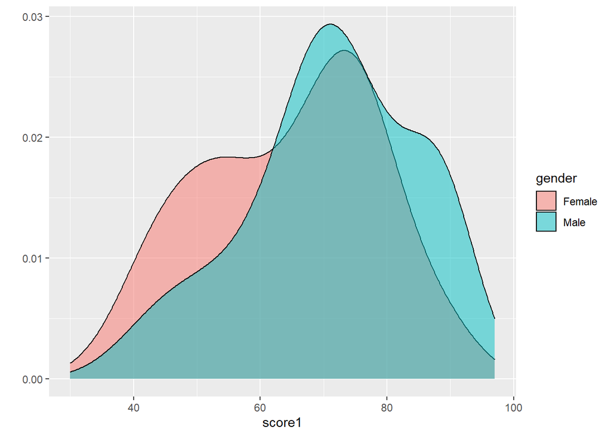

```r
# Density plots
qplot(fill = gender,
      x = score1,
      data = sdata,
      geom = "density",
      alpha = I(0.5),
      adjust = 2
      )
```

Let’s check if the populations have the same variance.

```r
x <- subset(sdata, gender=="Male")$score1
y <- subset(sdata, gender=="Female")$score1
var.test(x, y)
```

```
##
##  F test to compare two variances
##
## data:  x and y
## F = 0.95025, num df = 2625, denom df = 2265, p-value = 0.2078
## alternative hypothesis: true ratio of variances is not equal to 1
## 95 percent confidence interval:
##  0.87752 1.02877
## sample estimates:
## ratio of variances
##          0.9502524
```

As p-value > 0.05, the null hypothesis is not rejected and the variances are equal.

Checking assumptions: The two samples are random and independent. As the sample size is large enough, normality is not important. The variances are equal.

```r
t.test(x=x, y=y, alternative = "two.sided", var.equal = TRUE,
       conf.level = 0.95)
```

```
##
##  Two Sample t-test
##
## data:  x and y
## t = 16.528, df = 4890, p-value < 2.2e-16
## alternative hypothesis: true difference in means is not equal to 0
## 95 percent confidence interval:
##  5.712622 7.250147
## sample estimates:
## mean of x mean of y
##  71.16717  64.68579
```

As p-value < 0.05, the null hypothesis is rejected. We can conclude that there is statistically significant difference between male and female students score1.

```r
rm(sdata, x, y)
```